# Reproducible Research Week 2 Project

## 1. Loading and preprocessing the data

The data can be read by using read.csv(). However, the ‘date’ variable needs to be converted from a character to a date format.

```r
activity <- read.csv("activity.csv")
# Convert the date from chr to date
dates <- strptime(activity$date, "%Y-%m-%d")
activity$dateFormatted <- dates
```

## 2. What is mean total number of steps taken per day?

2.1 - Calculate the total number of steps taken per day

```r
steps <- split(activity$steps, dates$yday)

totalStepsPerDay <- sapply(steps, sum, na.rm=TRUE)
totalStepsPerDay
```

```
##   274   275   276   277   278   279   280   281   282   283   284   285   286
##     0   126 11352 12116 13294 15420 11015     0 12811  9900 10304 17382 12426
##   287   288   289   290   291   292   293   294   295   296   297   298   299
## 15098 10139 15084 13452 10056 11829 10395  8821 13460  8918  8355  2492  6778
##   300   301   302   303   304   305   306   307   308   309   310   311   312
## 10119 11458  5018  9819 15414     0 10600 10571     0 10439  8334 12883  3219
##   313   314   315   316   317   318   319   320   321   322   323   324   325
##     0     0 12608 10765  7336     0    41  5441 14339 15110  8841  4472 12787
##   326   327   328   329   330   331   332   333   334
## 20427 21194 14478 11834 11162 13646 10183  7047     0
```

2.2 - Make a histogram of the total number of steps taken each day

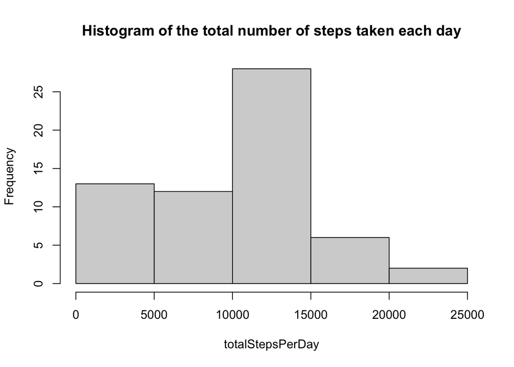

```r
hist(totalStepsPerDay, main="Histogram of the total number of steps taken each day")
```

2.3 - Calculate and report the mean and median of the total number of steps taken per day

```r
meanStepsPerDay <- sapply(steps, mean, na.rm=TRUE)
meanStepsPerDay
```

```
##        274        275        276        277        278        279        280
##        NaN  0.4375000 39.4166667 42.0694444 46.1597222 53.5416667 38.2465278
##        281        282        283        284        285        286        287
##        NaN 44.4826389 34.3750000 35.7777778 60.3541667 43.1458333 52.4236111
##        288        289        290        291        292        293        294
## 35.2048611 52.3750000 46.7083333 34.9166667 41.0729167 36.0937500 30.6284722
##        295        296        297        298        299        300        301
## 46.7361111 30.9652778 29.0104167  8.6527778 23.5347222 35.1354167 39.7847222
##        302        303        304        305        306        307        308
## 17.4236111 34.0937500 53.5208333        NaN 36.8055556 36.7048611        NaN
##        309        310        311        312        313        314        315
## 36.2465278 28.9375000 44.7326389 11.1770833        NaN        NaN 43.7777778
##        316        317        318        319        320        321        322
## 37.3784722 25.4722222        NaN  0.1423611 18.8923611 49.7881944 52.4652778
##        323        324        325        326        327        328        329
## 30.6979167 15.5277778 44.3993056 70.9270833 73.5902778 50.2708333 41.0902778
##        330        331        332        333        334
## 38.7569444 47.3819444 35.3576389 24.4687500        NaN
```

```r
medianStepsPerDay <- sapply(steps, median, na.rm=TRUE)
medianStepsPerDay
```

```
## 274 275 276 277 278 279 280 281 282 283 284 285 286 287 288 289 290 291 292 293
##  NA   0   0   0   0   0   0  NA   0   0   0   0   0   0   0   0   0   0   0   0
## 294 295 296 297 298 299 300 301 302 303 304 305 306 307 308 309 310 311 312 313
##   0   0   0   0   0   0   0   0   0   0   0  NA   0   0  NA   0   0   0   0  NA
## 314 315 316 317 318 319 320 321 322 323 324 325 326 327 328 329 330 331 332 333
##  NA   0   0   0  NA   0   0   0   0   0   0   0   0   0   0   0   0   0   0   0
## 334
##  NA
```

## 3. What is the average daily activity pattern?

3.1 - Make a time series plot of the 5-minute interval (x-axis) and the average number of steps taken, averaged across all days (y-axis)

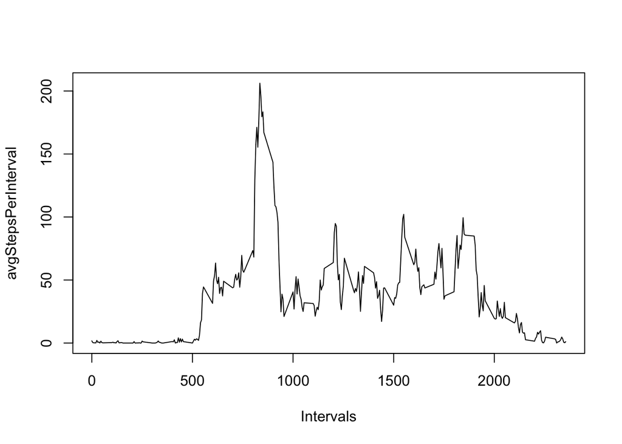

```r
intervals <- split(activity$steps, activity$interval)
avgStepsPerInterval <- sapply(intervals, mean, na.rm = TRUE)

plot(names(intervals), avgStepsPerInterval, type="l", xlab="Intervals")
```

```r
max(avgStepsPerInterval)
```

```
## [1] 206.1698
```

## 4. Imputing missing values

4.1 - Calculate and report the total number of missing values in the dataset

```r
isna <- is.na(activity$steps)
sum(isna)
```

```
## [1] 2304
```

4.2 - Devise a strategy for filling in all of the missing values in the dataset. The strategy does not need to be sophisticated. For example, you could use the mean/median for that day, of the mean for that 5-minute interval, etc.

```r
# For days where all the entries are N/A, just put 0 - we can't impute any information
meanStepsPerDay[is.nan(meanStepsPerDay)] <- 0
# Find values that are NA and replace them with the mean for that day.
means <- rep(meanStepsPerDay, 288)
rawData <- activity$steps
rawNA <- is.na(rawData)
rawData[rawNA] <- means[rawNA]
```

4.3 - Create a new dataset that is equal to the original dataset but with the missing data filled in

```r
newActivity <- activity
newActivity$steps <- rawData
```

[figure not shown]

```r
newSteps <- split(activity$steps, dates$yday)

newTotalStepsPerDay <- sapply(newSteps, sum, na.rm=TRUE)
hist(newTotalStepsPerDay, main="Histogram of total steps per day - with imputed values")
```

```r
newMeanStepsPerDay <- sapply(newSteps, mean, na.rm=TRUE)
newMeanStepsPerDay
```

```
##        274        275        276        277        278        279        280
##        NaN  0.4375000 39.4166667 42.0694444 46.1597222 53.5416667 38.2465278
##        281        282        283        284        285        286        287
##        NaN 44.4826389 34.3750000 35.7777778 60.3541667 43.1458333 52.4236111
##        288        289        290        291        292        293        294
## 35.2048611 52.3750000 46.7083333 34.9166667 41.0729167 36.0937500 30.6284722
##        295        296        297        298        299        300        301
## 46.7361111 30.9652778 29.0104167  8.6527778 23.5347222 35.1354167 39.7847222
##        302        303        304        305        306        307        308
## 17.4236111 34.0937500 53.5208333        NaN 36.8055556 36.7048611        NaN
##        309        310        311        312        313        314        315
## 36.2465278 28.9375000 44.7326389 11.1770833        NaN        NaN 43.7777778
##        316        317        318        319        320        321        322
## 37.3784722 25.4722222        NaN  0.1423611 18.8923611 49.7881944 52.4652778
##        323        324        325        326        327        328        329
## 30.6979167 15.5277778 44.3993056 70.9270833 73.5902778 50.2708333 41.0902778
##        330        331        332        333        334
## 38.7569444 47.3819444 35.3576389 24.4687500        NaN
```

```r
newMedianStepsPerDay <- sapply(newSteps, median, na.rm=TRUE)
newMedianStepsPerDay
```

```
## 274 275 276 277 278 279 280 281 282 283 284 285 286 287 288 289 290 291 292 293
##  NA   0   0   0   0   0   0  NA   0   0   0   0   0   0   0   0   0   0   0   0
## 294 295 296 297 298 299 300 301 302 303 304 305 306 307 308 309 310 311 312 313
##   0   0   0   0   0   0   0   0   0   0   0  NA   0   0  NA   0   0   0   0  NA
## 314 315 316 317 318 319 320 321 322 323 324 325 326 327 328 329 330 331 332 333
##  NA   0   0   0  NA   0   0   0   0   0   0   0   0   0   0   0   0   0   0   0
## 334
##  NA
```

## 5 - Are there differences in activity patterns between weekdays and weekends?

5.1 - Create a new factor variable in the dataset with two levels - “weekday” and “weekend” indicating whether a given date is a weekday or weekend day

```r
# Classify the days type in each date using the number of the 'wday' property in 'dates'
daysoftheweek <- dates$wday
classifiedDays <- rep(0, length(daysoftheweek)-1)
classifiedDays[daysoftheweek >= 1 & daysoftheweek <= 5] <- 1
classifiedDays[daysoftheweek == 6 | daysoftheweek == 0] <- 2
newActivity$DayType <- factor(classifiedDays, levels=c(1,2), labels=c("weekday", "weekend"))
```

5.2 - Make a panel plot containing a time series plot (i.e. type = “l”) of the 5-minute interval (x-axis) and the average number of steps taken, averaged across all weekday days or weekend days (y-axis). See the README file in the GitHub repository to see an example of what this plot should look like using simulated data

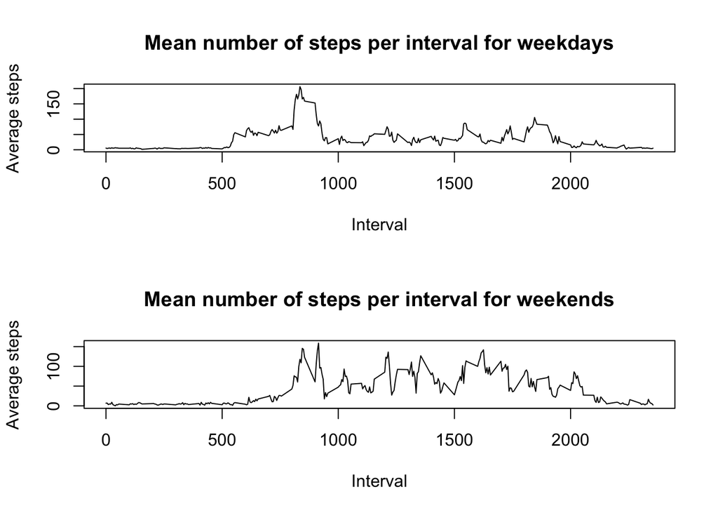

```r
activityWeekdays <- newActivity[newActivity$DayType == "weekday", ]
weekdaySplit <- split(activityWeekdays$steps, activityWeekdays$interval)

activityWeekends <- newActivity[newActivity$DayType == "weekend", ]
weekendSplit <- split(activityWeekends$steps, activityWeekends$interval)

meanStepsPerWeekday <- sapply(weekdaySplit, mean)
meanStepsPerWeekend <- sapply(weekendSplit, mean)


par(mfcol=c(2,1))
plot(names(intervals), meanStepsPerWeekday, type ="l", main="Mean number of steps per interval for weekdays", xlab="Interval", ylab="Average steps")
plot(names(intervals), meanStepsPerWeekend, type="l", main="Mean number of steps per interval for weekends", xlab="Interval", ylab="Average steps")
```